# Logistic Regression to Find Contributing Factors to Heart Disease

Setsuka Aust

4/11/2019

```r
install.packages("pROC")
library(pROC)
install.packages("PRROC")
library(PRROC)
```

## Reading and preprocessing the data set

The dataset obtained is of heart disease patients. The variable of interest, “output”, indicates whether a patient has heart disease. The dataset contains several relevant variables that are known indicators of heart disease.

The dataset was processed in a similar manner to the example provided.

```r
heart = read.table("https://raw.githubusercontent.com/grbruns/cst383/master/heart.dat", quote = "/")
names(heart) <- c("AGE", "SEX", "CHESTPAIN", "RESTBP", "CHOL",
                   "SUGAR", "ECG", "MAXHR", "ANGINA", "DEP", "EXERCISE", "FLUOR",
                   "THAL", "OUTPUT")
 names(heart) = tolower(names(heart))

 heart$output = heart$output - 1


 heart$sex = factor(heart$sex)
 heart$sugar = factor(heart$sugar)
 heart$angina = factor(heart$angina)
 heart$chestpain = factor(heart$chestpain)
 heart$ecg = factor(heart$ecg)
 heart$thal = factor(heart$thal)
 heart$exercise = factor(heart$exercise)

 rv = c("age", "restbp", "chol", "maxhr", "dep")
```

## Data exploration

We are interested in understanding aspects of the dataset. This exploration will aid in our formation of a logistic regression model.

```r
attach(heart)
str(heart)
```

```
## 'data.frame':    270 obs. of  14 variables:
##  $ age      : num  70 67 57 64 74 65 56 59 60 63 ...
##  $ sex      : Factor w/ 2 levels "0","1": 2 1 2 2 1 2 2 2 2 1 ...
##  $ chestpain: Factor w/ 4 levels "1","2","3","4": 4 3 2 4 2 4 3 4 4 4 ...
##  $ restbp   : num  130 115 124 128 120 120 130 110 140 150 ...
##  $ chol     : num  322 564 261 263 269 177 256 239 293 407 ...
##  $ sugar    : Factor w/ 2 levels "0","1": 1 1 1 1 1 1 2 1 1 1 ...
##  $ ecg      : Factor w/ 3 levels "0","1","2": 3 3 1 1 3 1 3 3 3 3 ...
##  $ maxhr    : num  109 160 141 105 121 140 142 142 170 154 ...
##  $ angina   : Factor w/ 2 levels "0","1": 1 1 1 2 2 1 2 2 1 1 ...
##  $ dep      : num  2.4 1.6 0.3 0.2 0.2 0.4 0.6 1.2 1.2 4 ...
##  $ exercise : Factor w/ 3 levels "1","2","3": 2 2 1 2 1 1 2 2 2 2 ...
##  $ fluor    : num  3 0 0 1 1 0 1 1 2 3 ...
##  $ thal     : Factor w/ 3 levels "3","6","7": 1 3 3 3 1 3 2 3 3 3 ...
##  $ output   : num  1 0 1 0 0 0 1 1 1 1 ...
```

```r
head(heart)
```

```
##   age sex chestpain restbp chol sugar ecg maxhr angina dep exercise fluor
## 1  70   1         4    130  322     0   2   109      0 2.4        2     3
## 2  67   0         3    115  564     0   2   160      0 1.6        2     0
## 3  57   1         2    124  261     0   0   141      0 0.3        1     0
## 4  64   1         4    128  263     0   0   105      1 0.2        2     1
## 5  74   0         2    120  269     0   2   121      1 0.2        1     1
## 6  65   1         4    120  177     0   0   140      0 0.4        1     0
##   thal output
## 1    3      1
## 2    7      0
## 3    7      1
## 4    7      0
## 5    3      0
## 6    7      0
```

```r
summary(heart)
```

```
##       age        sex     chestpain     restbp           chol       sugar
##  Min.   :29.00   0: 87   1: 20     Min.   : 94.0   Min.   :126.0   0:230
##  1st Qu.:48.00   1:183   2: 42     1st Qu.:120.0   1st Qu.:213.0   1: 40
##  Median :55.00           3: 79     Median :130.0   Median :245.0
##  Mean   :54.43           4:129     Mean   :131.3   Mean   :249.7
##  3rd Qu.:61.00                     3rd Qu.:140.0   3rd Qu.:280.0
##  Max.   :77.00                     Max.   :200.0   Max.   :564.0
##  ecg         maxhr       angina       dep       exercise     fluor
##  0:131   Min.   : 71.0   0:181   Min.   :0.00   1:130    Min.   :0.0000
##  1:  2   1st Qu.:133.0   1: 89   1st Qu.:0.00   2:122    1st Qu.:0.0000
##  2:137   Median :153.5           Median :0.80   3: 18    Median :0.0000
##          Mean   :149.7           Mean   :1.05            Mean   :0.6704
##          3rd Qu.:166.0           3rd Qu.:1.60            3rd Qu.:1.0000
##          Max.   :202.0           Max.   :6.20            Max.   :3.0000
##  thal        output
##  3:152   Min.   :0.0000
##  6: 14   1st Qu.:0.0000
##  7:104   Median :0.0000
##          Mean   :0.4444
##          3rd Qu.:1.0000
##          Max.   :1.0000
```

From the summary of the data, it is interesting to note the uneven distribution in some of the categorical variables. These include “sex”, a high amount of “chest pain” in level 4 category, only 2 “ECG” of level 1, and “thal”. Having a smaller sample space in some of these categories could negatively skew interpretations.

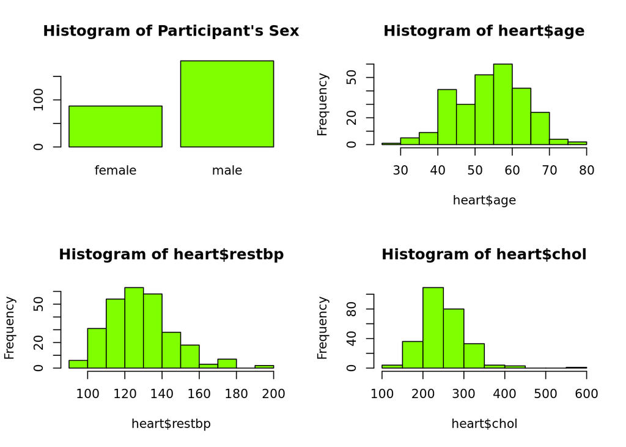

```r
par(mfrow=c(2,2))
barplot(c(87,183), names.arg = c("female", "male") , col = 'chartreuse', main = "Histogram of Participant's Sex")
hist(heart$age, col = 'chartreuse')
hist(heart$restbp, col = 'chartreuse' )
hist(heart$chol, col = 'chartreuse')
```

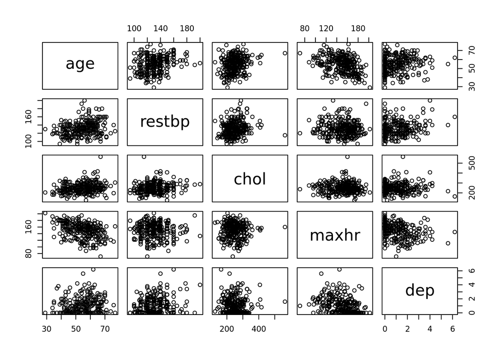

```r
pairs(heart[,rv])
```

```r
cor(heart[,rv])
```

```
##               age      restbp        chol       maxhr         dep
## age     1.0000000  0.27305280  0.22005631 -0.40221545  0.19423394
## restbp  0.2730528  1.00000000  0.17301918 -0.03913566  0.22279983
## chol    0.2200563  0.17301918  1.00000000 -0.01873919  0.02770915
## maxhr  -0.4022154 -0.03913566 -0.01873919  1.00000000 -0.34904540
## dep     0.1942339  0.22279983  0.02770915 -0.34904540  1.00000000
```

Issues arising from co-linear variables in our model appear to not be of a concern. VIF testing can also prove this to be true.

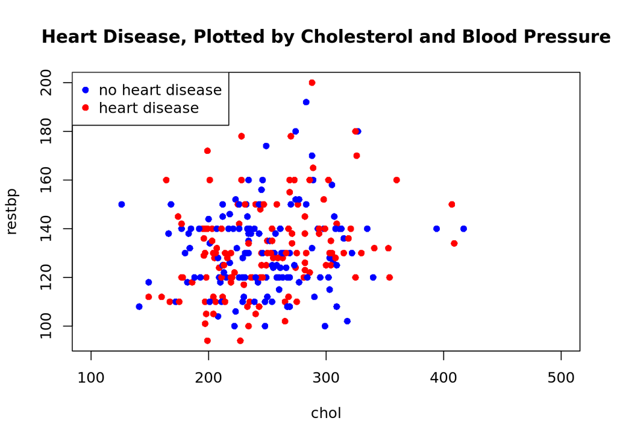

```r
plot(restbp~chol, col = c('blue' , 'red'), xlim = c(100,500), pch = 16, main = "Heart Disease, Plotted by Cholesterol and Blood Pressure")
legend("topleft", legend=c("no heart disease", "heart disease"), pch=16, col=c('blue', 'red'))
```

## Building a logistic regression model

```r
source("https://raw.githubusercontent.com/grbruns/cst383/master/lin-regr-util.R")

 set.seed(1)

 splits = split_data(heart, frac=c(3,1))
 tr_dat = splits[[1]]
 te_dat = splits[[2]]
```

```r
fit1 = glm(output ~ chol + restbp + age + exercise , data=tr_dat, family=binomial)
```

Based on existing research (http://time.com/3712478/predict-heart-attack-risk/), significant predictors of heart disease are supposedly Cholesterol and Blood Pressure. For this reason, those shall be included in the model. Considerations into inclusion of variables “angina” and “chestpain” were made, but since early risk detection of heart disease is a more desireable result, and chest pains usually are immediate precursors of heart disease, they were not included in this first model.

```r
summary(fit1)
```

```
##
## Call:
## glm(formula = output ~ chol + restbp + age + exercise, family = binomial,
##     data = tr_dat)
##
## Deviance Residuals:
##     Min       1Q   Median       3Q      Max
## -1.8995  -0.8955  -0.4936   0.9059   2.2007
##
## Coefficients:
##              Estimate Std. Error z value Pr(>|z|)
## (Intercept) -5.918931   1.562220  -3.789 0.000151 ***
## chol         0.004525   0.003454   1.310 0.190140
## restbp       0.008251   0.009811   0.841 0.400346
## age          0.046449   0.019494   2.383 0.017186 *
## exercise2    1.725096   0.335393   5.144  2.7e-07 ***
## exercise3    1.956143   0.684934   2.856 0.004291 **
## ---
## Signif. codes:  0 '***' 0.001 '**' 0.01 '*' 0.05 '.' 0.1 ' ' 1
##
## (Dispersion parameter for binomial family taken to be 1)
##
##     Null deviance: 277.21  on 200  degrees of freedom
## Residual deviance: 229.91  on 195  degrees of freedom
## AIC: 241.91
##
## Number of Fisher Scoring iterations: 4
```

Surprisingly, both “chol” and “restbp” are not signficant predictors of heart disease, given the other variables in the model.

## Classifying test data

Using our trained model on test data, we will assess the accuracy of the model.

```r
y = predict(fit1, newdata=te_dat, type="response")
predicts = as.numeric(y > 0.5)
actuals = te_dat$output
conf_mtx = table(predicts, actuals)
conf_mtx
```

```
##         actuals
## predicts  0  1
##        0 28 11
##        1 13 17
```

```r
(conf_mtx[1,1] + conf_mtx[2,2])/length(y)
```

```
## [1] 0.6521739
```

Our model has achieved .65 percent accuracy, given a .5 classification threshold.

If the threshold is changed to .6, we obtain better accuracy. This may suggest that classification in logisitic regression models may need to be more conservative in heart disease prediction. Though, it is likely not generalizable and can only find significance based on this model and sample size. Further analysis would be required.

```r
y = predict(fit1, newdata=te_dat, type="response")
predicts = as.numeric(y > 0.6)
actuals = te_dat$output
conf_mtx = table(predicts, actuals)
conf_mtx
```

```
##         actuals
## predicts  0  1
##        0 34 13
##        1  7 15
```

```r
(conf_mtx[1,1] + conf_mtx[2,2])/length(y)
```

```
## [1] 0.7101449
```

## Assessing the Model

Currently the model predicts a moderate amount of heart disease patients correctly.

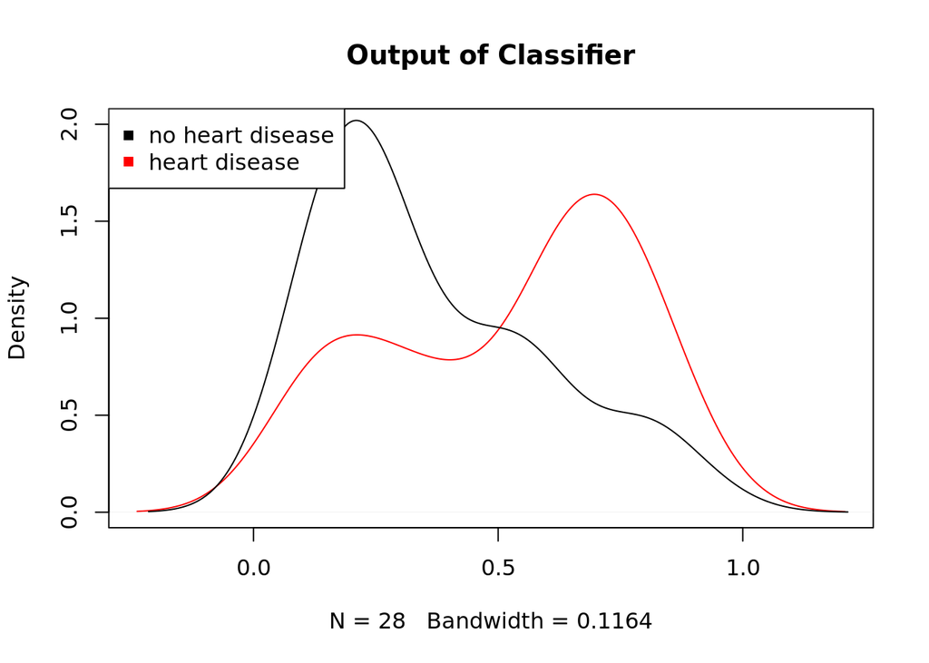

```r
plot(density(y[actuals == 1]), ylim = c(0,2), col = 'red', main = "Output of Classifier")
lines(density(y[actuals == 0]))
legend("topleft", legend=c("no heart disease", "heart disease"), pch=15, col=c('black', 'red'))
```

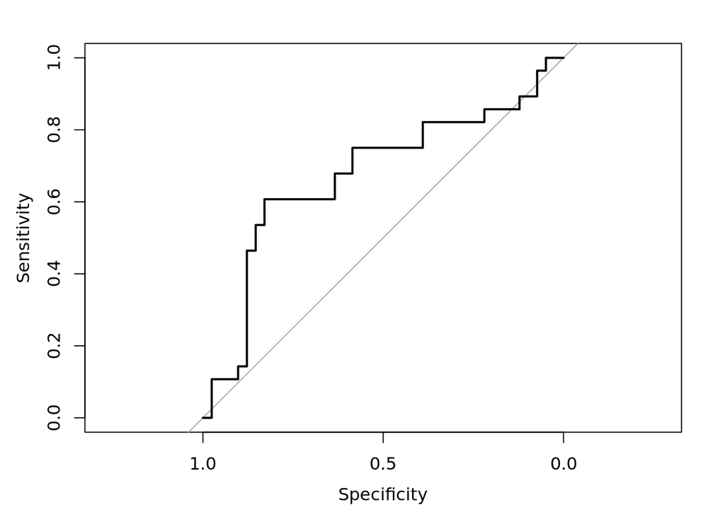

```r
plot(roc(actuals~y))
```

```r
auc(roc(actuals~y))
```

```
## Area under the curve: 0.6733
```

Based on the ROC plot and AUC, we have obtained a classifier that has a probability of correctly predicting heart disease of .67

```r
prec_recall_summary = function(predicts, actuals) {
   thresh = seq(0, 1, length.out=50)
   prec_rec = data.frame()
   actuals = factor(as.numeric(actuals))
   for (th in thresh) {
     predicts = factor(as.numeric(y >= th), levels=c("0","1"))
     prec_rec = rbind(prec_rec, as.vector(table(predicts, actuals)))
   }
   names(prec_rec) = c("TN", "FP", "FN", "TP")
   prec_rec$threshold = thresh
  prec_rec$precision = prec_rec$TP/(prec_rec$TP + prec_rec$FP)
   prec_rec$recall    = prec_rec$TP/(prec_rec$TP + prec_rec$FN)
   prec_rec$false_pos = prec_rec$FP/(prec_rec$FP + prec_rec$TN)
   return(prec_rec)
}

pr1 = prec_recall_summary(predicts, actuals)
attach(pr1)
plot(precision~threshold, type = 'l')
```

[output not shown]

```r
plot(recall~threshold, type = 'l')
```

[output not shown]

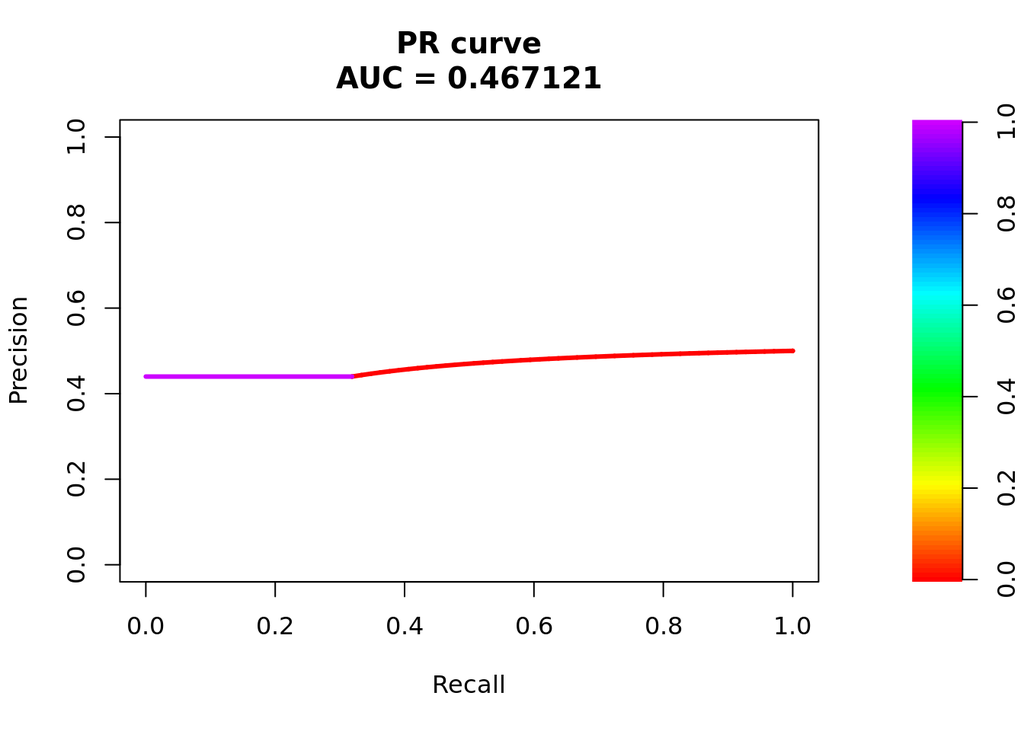

```r
plot(pr.curve(predicts, actuals, curve = TRUE))
```

## Model 2

The initial model is a useful staring point, though it could be useful to use automated techniques to try to arrive at a stronger model.

Variable/model selection can be used to obtain potentially stronger models.

The following models will be obtained using backwards and forward elimination, respectively. The base model’s predictor variable was determined based on the significance of the “fluor” variable in the full model.

```r
full = glm(output~.,  data=tr_dat, family=binomial)
summary(full)
```

```
##
## Call:
## glm(formula = output ~ ., family = binomial, data = tr_dat)
##
## Deviance Residuals:
##     Min       1Q   Median       3Q      Max
## -2.6363  -0.4767  -0.1187   0.2797   2.9668
##
## Coefficients:
##              Estimate Std. Error z value Pr(>|z|)
## (Intercept) -6.764223   3.674872  -1.841 0.065670 .
## age          0.002234   0.032293   0.069 0.944856
## sex1         1.397205   0.680543   2.053 0.040066 *
## chestpain2   0.897966   1.038557   0.865 0.387243
## chestpain3  -0.141226   0.883447  -0.160 0.872993
## chestpain4   1.539926   0.879749   1.750 0.080047 .
## restbp       0.019461   0.014934   1.303 0.192540
## chol         0.011041   0.005884   1.876 0.060617 .
## sugar1      -0.143963   0.693016  -0.208 0.835436
## ecg1         0.158992   3.774041   0.042 0.966397
## ecg2         1.113938   0.519408   2.145 0.031982 *
## maxhr       -0.024803   0.014279  -1.737 0.082389 .
## angina1      1.024738   0.552794   1.854 0.063776 .
## dep          0.693889   0.310663   2.234 0.025511 *
## exercise2    0.569104   0.558647   1.019 0.308337
## exercise3    0.730016   1.207845   0.604 0.545581
## fluor        0.678838   0.301972   2.248 0.024575 *
## thal6        0.951278   1.122636   0.847 0.396794
## thal7        1.925876   0.570866   3.374 0.000742 ***
## ---
## Signif. codes:  0 '***' 0.001 '**' 0.01 '*' 0.05 '.' 0.1 ' ' 1
##
## (Dispersion parameter for binomial family taken to be 1)
##
##     Null deviance: 277.21  on 200  degrees of freedom
## Residual deviance: 123.51  on 182  degrees of freedom
## AIC: 161.51
##
## Number of Fisher Scoring iterations: 6
```

```r
base = glm(output~fluor)
```

```r
back.glm = step(full, scope = list(lower=~1, upper = full), direction = "backward", trace = FALSE)

summary(back.glm)
```

```
##
## Call:
## glm(formula = output ~ sex + chestpain + chol + ecg + maxhr +
##     angina + dep + fluor + thal, family = binomial, data = tr_dat)
##
## Deviance Residuals:
##     Min       1Q   Median       3Q      Max
## -2.4753  -0.4699  -0.1306   0.3206   2.7940
##
## Coefficients:
##              Estimate Std. Error z value Pr(>|z|)
## (Intercept) -3.904685   2.583996  -1.511 0.130762
## sex1         1.172118   0.631504   1.856 0.063443 .
## chestpain2   0.601284   0.987994   0.609 0.542796
## chestpain3  -0.296283   0.865638  -0.342 0.732147
## chestpain4   1.302917   0.841491   1.548 0.121539
## chol         0.012274   0.005577   2.201 0.027741 *
## ecg1         0.619882   3.609637   0.172 0.863650
## ecg2         1.137413   0.508032   2.239 0.025165 *
## maxhr       -0.025240   0.012835  -1.967 0.049238 *
## angina1      1.087100   0.535952   2.028 0.042524 *
## dep          0.872274   0.281198   3.102 0.001922 **
## fluor        0.594276   0.267889   2.218 0.026530 *
## thal6        1.229356   1.108086   1.109 0.267240
## thal7        2.011716   0.559943   3.593 0.000327 ***
## ---
## Signif. codes:  0 '***' 0.001 '**' 0.01 '*' 0.05 '.' 0.1 ' ' 1
##
## (Dispersion parameter for binomial family taken to be 1)
##
##     Null deviance: 277.21  on 200  degrees of freedom
## Residual deviance: 126.37  on 187  degrees of freedom
## AIC: 154.37
##
## Number of Fisher Scoring iterations: 6
```

```r
y2 = predict(back.glm, newdata=te_dat, type="response")
predicts2 = as.numeric(y2 > 0.8)
actuals = te_dat$output
conf_mtx2 = table(predicts2, actuals)
conf_mtx2
```

```
##          actuals
## predicts2  0  1
##         0 36  9
##         1  5 19
```

```r
(conf_mtx2[1,1] + conf_mtx2[2,2])/length(y2)
```

```
## [1] 0.7971014
```

This model allows for a higher threshold tolerance, without sacrificing accuracy of predictions. This model would be useful if mitigation of false postitives were a concern.

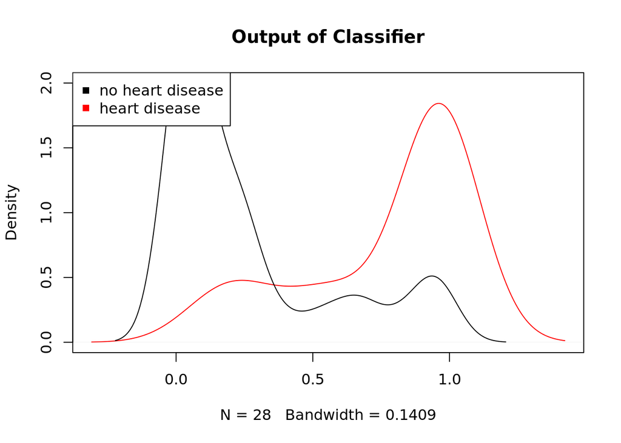

```r
plot(density(y2[actuals == 1]), ylim = c(0,2), col = 'red', main = "Output of Classifier")
lines(density(y2[actuals == 0]))
legend("topleft", legend=c("no heart disease", "heart disease"), pch=15, col=c('black', 'red'))
```

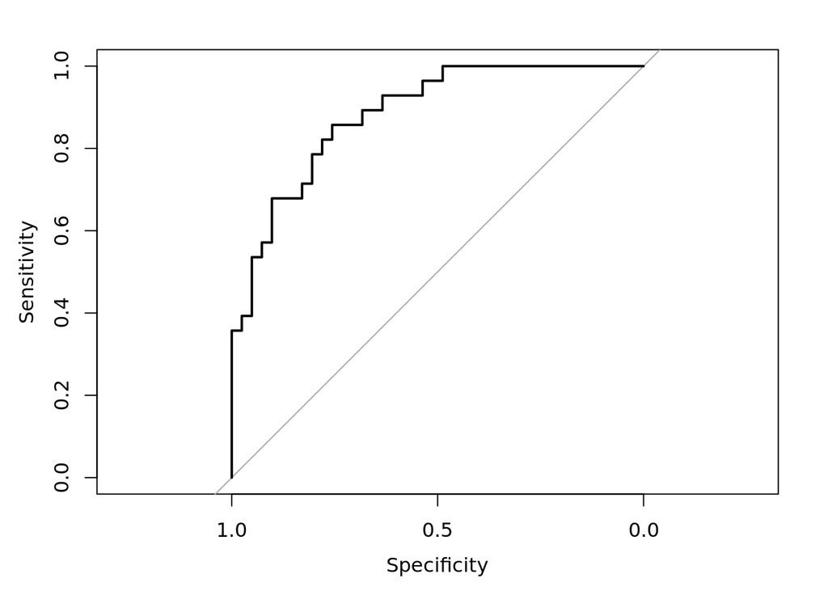

```r
plot(roc(actuals~y2))
```

```r
auc(roc(actuals~y2))
```

```
## Area under the curve: 0.8833
```

Based on the ROC plot and AUC, we have obtained a classifier that has a probability of correctly predicting heart disease of .88. This indicates a stronger model.

```r
pr2 = prec_recall_summary(predicts2, actuals)
plot(precision~threshold, data = pr2, type = 'l')
```

[output not shown]

```r
plot(recall~threshold, data = pr2, type = 'l')
```

[output not shown]

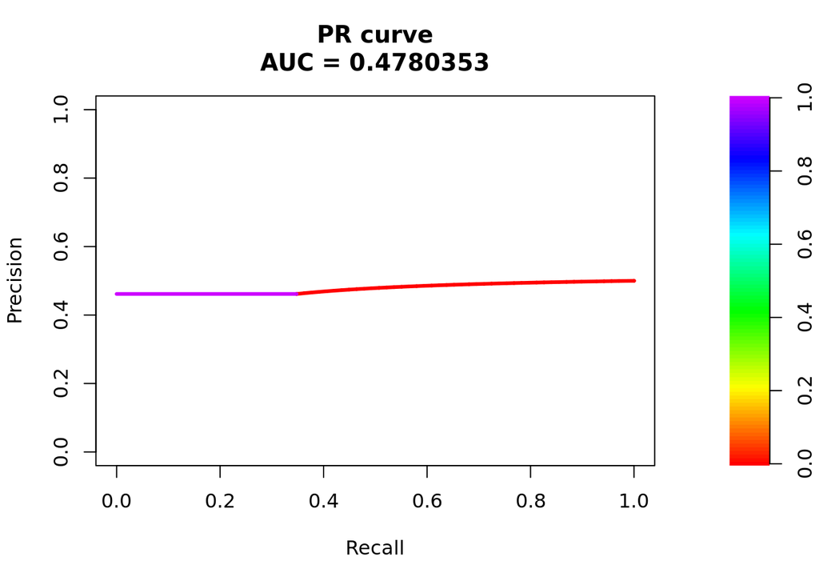

```r
plot(pr.curve(predicts2, actuals, curve = TRUE))
```

The interpretation of this PR curve is that there is little trade off for precision, over recall.

## Model 3

```r
forward.glm = step(base, scope = list(lower=~1, upper = full), direction = "forward", trace = FALSE)
summary(forward.glm)
```

```
##
## Call:
## glm(formula = output ~ fluor + thal + chestpain + dep + maxhr +
##     sex + angina + exercise + restbp)
##
## Deviance Residuals:
##      Min        1Q    Median        3Q       Max
## -0.95567  -0.20527  -0.03717   0.16378   0.98414
##
## Coefficients:
##              Estimate Std. Error t value Pr(>|t|)
## (Intercept) -0.162862   0.265469  -0.613 0.540098
## fluor        0.124026   0.024068   5.153 5.12e-07 ***
## thal6        0.040508   0.102219   0.396 0.692225
## thal7        0.218067   0.052567   4.148 4.56e-05 ***
## chestpain2   0.120611   0.096337   1.252 0.211723
## chestpain3   0.073773   0.087902   0.839 0.402107
## chestpain4   0.309632   0.087230   3.550 0.000459 ***
## dep          0.049880   0.024803   2.011 0.045367 *
## maxhr       -0.002011   0.001092  -1.841 0.066814 .
## sex1         0.159077   0.049714   3.200 0.001549 **
## angina1      0.093393   0.052311   1.785 0.075390 .
## exercise2    0.117430   0.053810   2.182 0.029994 *
## exercise3    0.012800   0.103577   0.124 0.901742
## restbp       0.002328   0.001233   1.888 0.060123 .
## ---
## Signif. codes:  0 '***' 0.001 '**' 0.01 '*' 0.05 '.' 0.1 ' ' 1
##
## (Dispersion parameter for gaussian family taken to be 0.1160058)
##
##     Null deviance: 66.667  on 269  degrees of freedom
## Residual deviance: 29.697  on 256  degrees of freedom
## AIC: 200.24
##
## Number of Fisher Scoring iterations: 2
```

```r
y3 = predict(forward.glm, newdata=te_dat, type="response")
predicts3 = as.numeric(y3 > 0.5)
actuals = te_dat$output
conf_mtx3 = table(predicts3, actuals)
conf_mtx3
```

```
##          actuals
## predicts3  0  1
##         0 36  2
##         1  5 26
```

```r
(conf_mtx3[1,1] + conf_mtx3[2,2])/length(y3)
```

```
## [1] 0.8985507
```

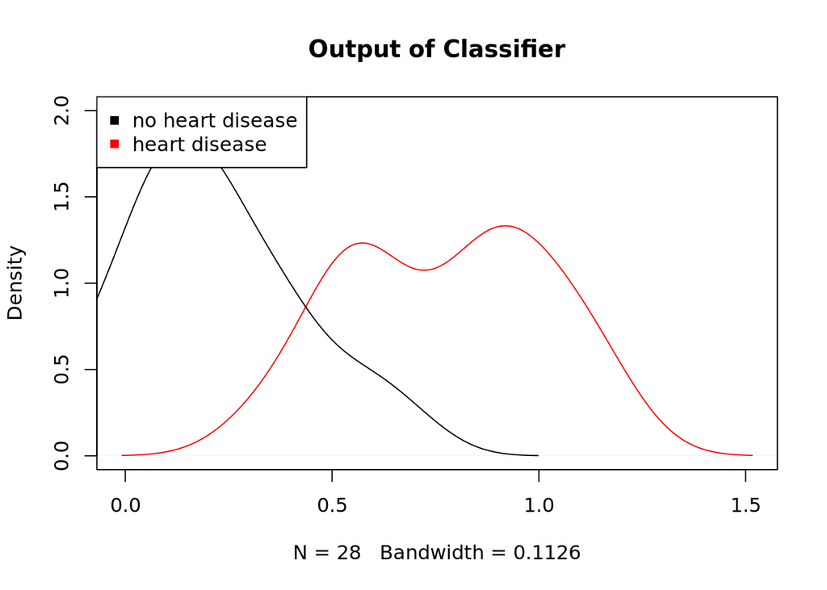

```r
plot(density(y3[actuals == 1]), ylim = c(0,2), col = 'red', main = "Output of Classifier")
lines(density(y3[actuals == 0]))
legend("topleft", legend=c("no heart disease", "heart disease"), pch=15, col=c('black', 'red'))
```

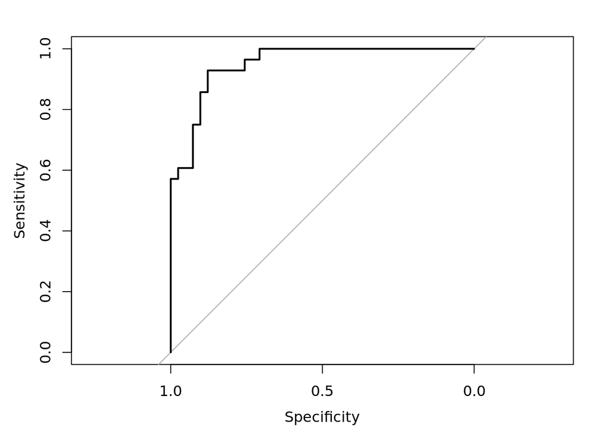

```r
plot(roc(actuals~y3))
```

```r
auc(roc(actuals~y3))
```

```
## Area under the curve: 0.9503
```

Based on the ROC plot and AUC, we have obtained a classifier that has a probability of correctly predicting heart disease of .95.

```r
pr3 = prec_recall_summary(predicts3, actuals)
plot(precision~threshold, data = pr3, type = 'l')
```

[output not shown]

```r
plot(recall~threshold, data = pr3, type = 'l')
```

[output not shown]

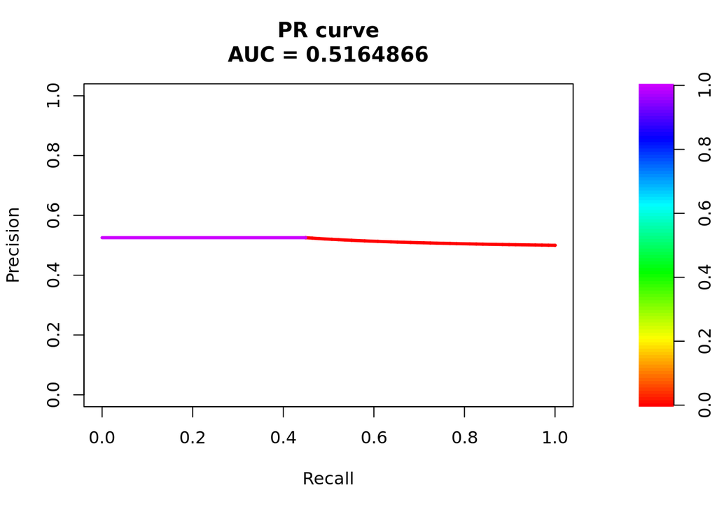

```r
plot(pr.curve(predicts3, actuals, curve = TRUE))
```

This PR curve has similar interpretations as previous ones.